# TensorFlow basics

TensorFlow is a Google library made specifically for neural networks. In this note, we will be introduced to some basics of this main library, as well as the probability module. The topics discussed are:

- TensorFlow basics
  - Optimization with standard gradient descent
  - Slicing and indexing data set
- TensorFlow Probability
  - Generating random data
  - Posterior probability using uniform priors
  - Posterior sampling

```python
# pip install -U TensorFlow
```

```python
import tensorflow as tf
```

```python
tf.add(1,2)
```

```
<tf.Tensor: shape=(), dtype=int32, numpy=3>
```

```python
tf.add([1.,2.], [3, 4])
```

```
<tf.Tensor: shape=(2,), dtype=float32, numpy=array([4., 6.], dtype=float32)>
```

One thing to note with tensorflow is the types need to be consistent within arrays. Cannot have `1`and `1.` in same array, vector, or matrix. (Well, this worked for me but not him..)

```python
tf.add([1,2], [3,4])
```

```
<tf.Tensor: shape=(2,), dtype=int32, numpy=array([4, 6])>
```

```python
tf.square(123)
```

```
<tf.Tensor: shape=(), dtype=int32, numpy=15129>
```

```python
tf.constant([[1,3,4],[5,6,7]])
```

```
<tf.Tensor: shape=(2, 3), dtype=int32, numpy=
array([[1, 3, 4],
       [5, 6, 7]])>
```

```python
tf.linalg.inv([[1.,2.], [3.,4.]])
```

```
<tf.Tensor: shape=(2, 2), dtype=float32, numpy=
array([[-2.0000002 ,  1.0000001 ],
       [ 1.5000001 , -0.50000006]], dtype=float32)>
```

TensorFlow automatically uses float32 types, but can be changed. 16 is the fastest. Just keep in mind when error pop up.

# Optimization

```python
opt = tf.optimizers.SGD(learning_rate=0.3)
```

Standard gradient deriviation will get an objective function, find a starting point, and follow the steepest decent down to the global minimum.

```python
var = tf.Variable(2.0)
```

Variables are the counter-part to constants. Can also be scalars, vectors or matrices. Only difference is they can change, while constants can't.

```python
with tf.GradientTape() as tape:
    y = var**2 +1
```

```python
tape.gradient(y, var)
```

```
<tf.Tensor: shape=(), dtype=float32, numpy=4.0>
```

```python
loss = lambda : var**2 /1.5
```

```python
loss()
```

```
<tf.Tensor: shape=(), dtype=float32, numpy=2.6666667>
```

```python
opt.minimize(loss, [var])
```

```
<tf.Variable 'UnreadVariable' shape=() dtype=int64, numpy=1>
```

```python
var
```

[output not shown]

```python
var_vals, loss_vals = [], []
for _ in range(30):       # underscore is a valiad variable name, but means idc,dont worry about it
    opt.minimize(loss, [var])
    var_vals.append(var.numpy())
    loss_vals.append(loss())
```

```python
import matplotlib.pyplot as plt
%matplotlib inline
```

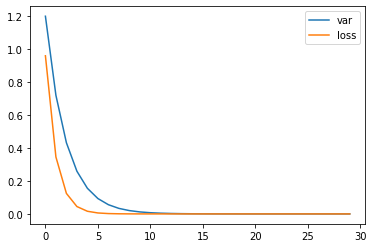

```python
plt.plot(var_vals)
plt.plot(loss_vals)
plt.legend(['var', 'loss'])
```

# Data sets

Can be nice to use pandas for preprocessing. But in industry, its a good idea to stick to as few libraries as possible. Tensorflow data sets are made for speed, whereas pandas is more for visualizing.

```python
ds = tf.data.Dataset.from_tensor_slices(list(range(12)))
```

```python
for i in ds.map(tf.square).shuffle(2).batch(3):
    print(i)
```

```
tf.Tensor([1 0 9], shape=(3,), dtype=int32)
tf.Tensor([ 4 25 16], shape=(3,), dtype=int32)
tf.Tensor([36 49 81], shape=(3,), dtype=int32)
tf.Tensor([100 121  64], shape=(3,), dtype=int32)
```

Want to try and do the data manipulations on the graphics card. No need to manipulate on CPU, then transfer over to GPU.

```python
ds.reduce(0, lambda state, value: state+value)
```

```
<tf.Tensor: shape=(), dtype=int32, numpy=66>
```

```python
state = 0
op = lambda state, value: state+value
for value in ds:
    state = op(state, value)
state
```

```
<tf.Tensor: shape=(), dtype=int32, numpy=66>
```

```python
ds.map(tf.square).reduce(0, tf.add)
```

```
<tf.Tensor: shape=(), dtype=int32, numpy=506>
```

# TensorFlow Probability

We will use this for Bayesian analysis using tensorflow.

```python
# pip install tensorflow_probability
```

```
^C
```

```python
import tensorflow as tf
import tensorflow_probability as tfp
```

# Generate data

Random sample from Binomial with N=60, and $\theta$=0.6

```python
tfd = tfp.distributions
```

```python
dist = tfd.Binomial(total_count=60, probs=0.6)  # to pull a sample from some random distribution
```

```python
sample = dist.sample(1)
sample  # happened to match his perfectly, but didnt have to!
```

```
<tf.Tensor: shape=(1,), dtype=float32, numpy=array([35.], dtype=float32)>
```